# Assignment 1

Arkaprabha Gun

2026-01-27

```r
addicts2 <- read_dta("data/addicts2.dta")

summary(addicts2)
```

```
##        id            clinic           status           survt
##  Min.   :  1.0   Min.   : 1.000   Min.   :0.0000   Min.   :   -9.0
##  1st Qu.: 65.5   1st Qu.: 1.000   1st Qu.:0.0000   1st Qu.:  169.0
##  Median :132.0   Median : 1.000   Median :1.0000   Median :  368.0
##  Mean   :134.7   Mean   : 1.431   Mean   :0.6276   Mean   :  549.1
##  3rd Qu.:206.5   3rd Qu.: 2.000   3rd Qu.:1.0000   3rd Qu.:  589.0
##  Max.   :267.0   Max.   :22.000   Max.   :1.0000   Max.   :35800.0
##      prison            dose
##  Min.   :0.0000   Min.   : 20.00
##  1st Qu.:0.0000   1st Qu.: 50.00
##  Median :0.0000   Median : 60.00
##  Mean   :0.4686   Mean   : 63.49
##  3rd Qu.:1.0000   3rd Qu.: 70.00
##  Max.   :1.0000   Max.   :800.00
```

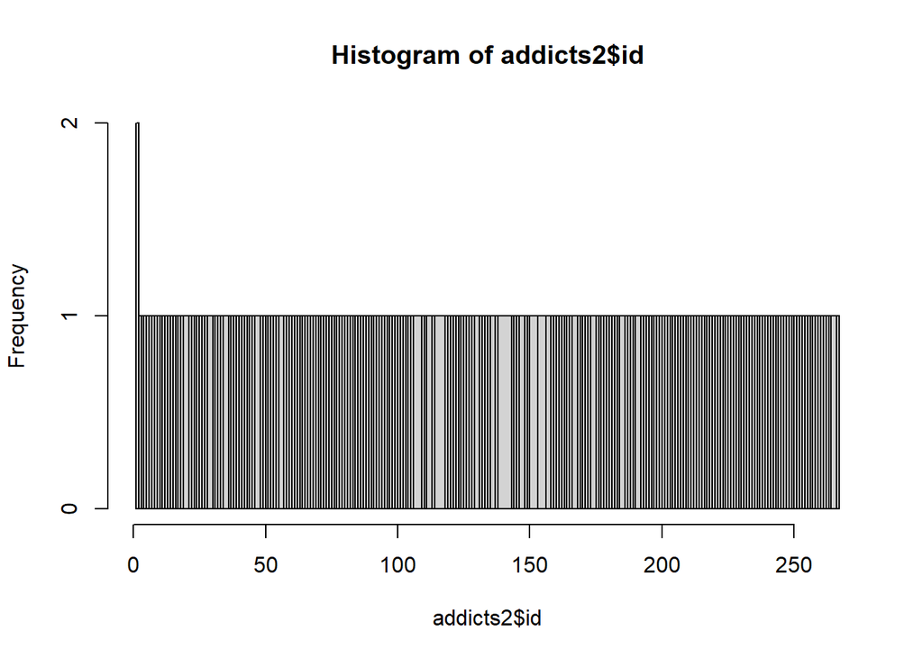

```r
hist(addicts2$id,breaks = unique(addicts2$id),freq = TRUE)
```

```r
# Check which records have clinic = 9 or 22
addicts2[addicts2$clinic %in% c(9, 22), ]
```

```
## # A tibble: 2 × 6
##      id clinic status survt prison  dose
##   <dbl>  <dbl>  <dbl> <dbl>  <dbl> <dbl>
## 1   199      9      1    49      0    60
## 2   249     22      0   394      1    80
```

```r
addicts2 <- addicts2[addicts2$clinic %in% c(1, 2) & addicts2$survt > 0 & addicts2$survt < 2000, ]


# Create a cleaned dataset excluding these problematic records
addicts_clean <- addicts2[addicts2$clinic %in% c(1, 2), ]

# Verify
table(addicts_clean$clinic)
```

```
##
##   1   2
## 161  74
```

```r
# Now fit the Kaplan-Meier curves with cleaned data
km_fit <- survfit(Surv(survt, status) ~ clinic, data = addicts_clean)

# Check the fit
km_fit
```

```
## Call: survfit(formula = Surv(survt, status) ~ clinic, data = addicts_clean)
##
##            n events median 0.95LCL 0.95UCL
## clinic=1 161    120    434     348     517
## clinic=2  74     28     NA     661      NA
```

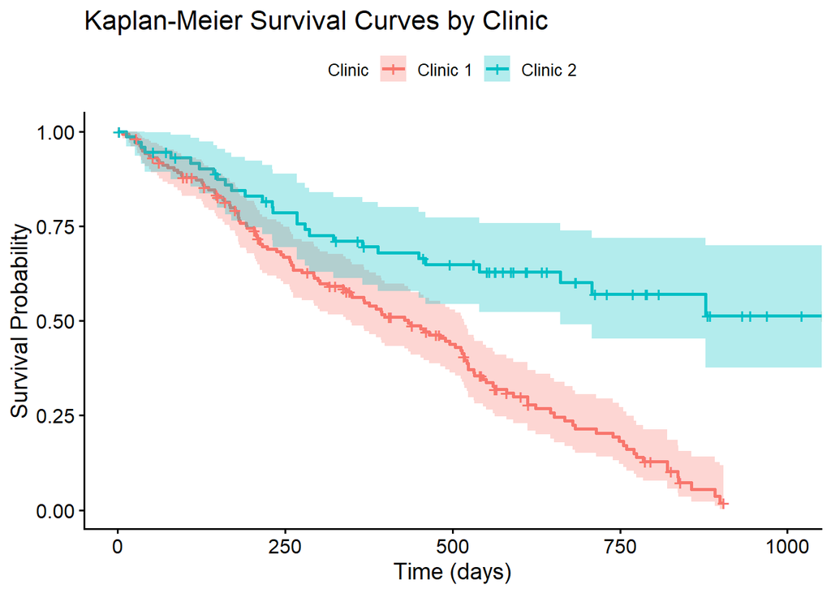

```r
# Generate the Kaplan-Meier plot with confidence intervals
ggsurvplot(
  km_fit,
  data = addicts_clean,
  conf.int = TRUE,
  pval = FALSE,
  risk.table = FALSE,
  xlab = "Time (days)",
  ylab = "Survival Probability",
  title = "Kaplan-Meier Survival Curves by Clinic",
  legend.title = "Clinic",
  legend.labs = c("Clinic 1", "Clinic 2")
)
```

```r
# Perform the log-rank test
logrank_test <- survdiff(Surv(survt, status) ~ clinic, data = addicts2)

# Display the results
logrank_test
```

```
## Call:
## survdiff(formula = Surv(survt, status) ~ clinic, data = addicts2)
##
##            N Observed Expected (O-E)^2/E (O-E)^2/V
## clinic=1 161      120     89.8      10.2      26.7
## clinic=2  74       28     58.2      15.7      26.7
##
##  Chisq= 26.7  on 1 degrees of freedom, p= 2e-07
```

The two survival curves are statistically significantly different (p < 0.001). We reject the null hypothesis that the survival curves are the same between the two clinics.

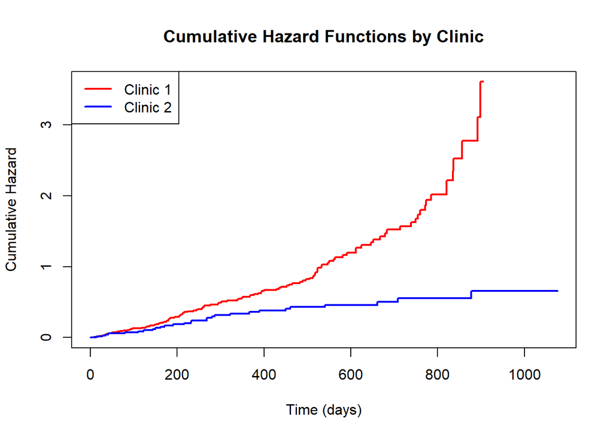

```r
plot(km_fit, fun="cumhaz", col=c("red", "blue"), lwd=2,
     xlab="Time (days)",
     ylab="Cumulative Hazard",
     main="Cumulative Hazard Functions by Clinic")
legend("topleft", c("Clinic 1", "Clinic 2"), col=c("red", "blue"), lty=1, lwd=2)
```

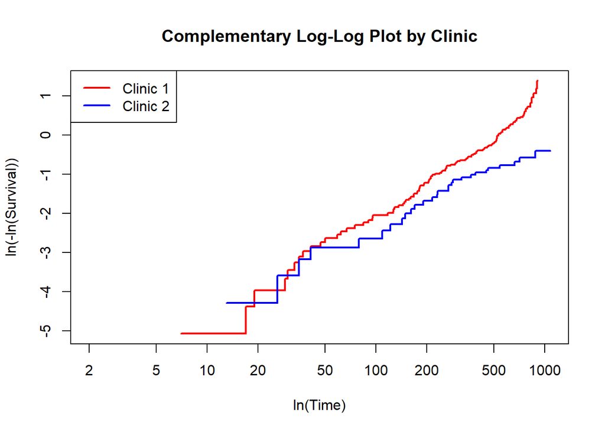

```r
plot(km_fit, fun="cloglog", col=c("red", "blue"), lwd=2,
     xlab="ln(Time)",
     ylab="ln(-ln(Survival))",
     main="Complementary Log-Log Plot by Clinic")
legend("topleft", c("Clinic 1", "Clinic 2"), col=c("red", "blue"), lty=1, lwd=2)
```

## Question 4

```r
# Fit Cox proportional hazards model
cox_model <- coxph(Surv(survt, status) ~ clinic + prison + dose, data = addicts2)

# Display the summary
summary(cox_model)
```

```
## Call:
## coxph(formula = Surv(survt, status) ~ clinic + prison + dose,
##     data = addicts2)
##
##   n= 235, number of events= 148
##
##             coef exp(coef)  se(coef)      z Pr(>|z|)
## clinic -0.998991  0.368251  0.215173 -4.643 3.44e-06 ***
## prison  0.340481  1.405624  0.168068  2.026   0.0428 *
## dose   -0.035388  0.965231  0.006422 -5.510 3.58e-08 ***
## ---
## Signif. codes:  0 '***' 0.001 '**' 0.01 '*' 0.05 '.' 0.1 ' ' 1
##
##        exp(coef) exp(-coef) lower .95 upper .95
## clinic    0.3683     2.7155    0.2415    0.5614
## prison    1.4056     0.7114    1.0111    1.9540
## dose      0.9652     1.0360    0.9532    0.9775
##
## Concordance= 0.665  (se = 0.025 )
## Likelihood ratio test= 63.19  on 3 df,   p=1e-13
## Wald test            = 53.13  on 3 df,   p=2e-11
## Score (logrank) test = 55.13  on 3 df,   p=6e-12
```

```r
# Create a nicer table format
library(broom)
tidy(cox_model, exponentiate = TRUE, conf.int = TRUE)
```

```
## # A tibble: 3 × 7
##   term   estimate std.error statistic      p.value conf.low conf.high
##   <chr>     <dbl>     <dbl>     <dbl>        <dbl>    <dbl>     <dbl>
## 1 clinic    0.368   0.215       -4.64 0.00000344      0.242     0.561
## 2 prison    1.41    0.168        2.03 0.0428          1.01      1.95
## 3 dose      0.965   0.00642     -5.51 0.0000000358    0.953     0.977
```

```r
# Test proportional hazards assumption
ph_test <- cox.zph(cox_model)

# Display the results
print(ph_test)
```

```
##         chisq df       p
## clinic 11.509  1 0.00069
## prison  0.961  1 0.32687
## dose    0.653  1 0.41915
## GLOBAL 12.844  3 0.00499
```

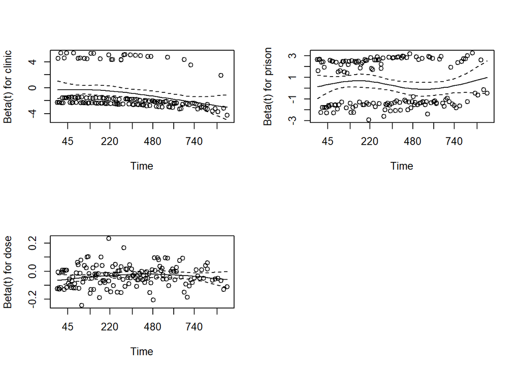

```r
# Plot the Schoenfeld residuals
par(mfrow=c(2,2))  # Create a 2x2 plot layout
plot(ph_test)
par(mfrow=c(1,1))  # Reset to single plot
```

```r
# Fit Cox model with time-varying clinic effect
cox_tv <- coxph(Surv(survt, status) ~ prison + dose + tt(clinic),
                data = addicts2,
                tt = function(x, t, ...) x * log(t))

# Get the results
summary(cox_tv)
```

```
## Call:
## coxph(formula = Surv(survt, status) ~ prison + dose + tt(clinic),
##     data = addicts2, tt = function(x, t, ...) x * log(t))
##
##   n= 235, number of events= 148
##
##                 coef exp(coef)  se(coef)      z Pr(>|z|)
## prison      0.362793  1.437339  0.168598  2.152   0.0314 *
## dose       -0.035336  0.965281  0.006465 -5.466 4.62e-08 ***
## tt(clinic) -0.192438  0.824946  0.038737 -4.968 6.77e-07 ***
## ---
## Signif. codes:  0 '***' 0.001 '**' 0.01 '*' 0.05 '.' 0.1 ' ' 1
##
##            exp(coef) exp(-coef) lower .95 upper .95
## prison        1.4373     0.6957    1.0329    2.0002
## dose          0.9653     1.0360    0.9531    0.9776
## tt(clinic)    0.8249     1.2122    0.7646    0.8900
##
## Concordance= 0.673  (se = 0.024 )
## Likelihood ratio test= 67.47  on 3 df,   p=1e-14
## Wald test            = 55.81  on 3 df,   p=5e-12
## Score (logrank) test = 58.79  on 3 df,   p=1e-12
```

```r
tidy(cox_tv, exponentiate = TRUE, conf.int = TRUE)
```

```
## # A tibble: 3 × 7
##   term       estimate std.error statistic      p.value conf.low conf.high
##   <chr>         <dbl>     <dbl>     <dbl>        <dbl>    <dbl>     <dbl>
## 1 prison        1.44    0.169        2.15 0.0314          1.03      2.00
## 2 dose          0.965   0.00647     -5.47 0.0000000462    0.953     0.978
## 3 tt(clinic)    0.825   0.0387      -4.97 0.000000677     0.765     0.890
```

```r
# Calculate clinic HR at median follow-up time
median_time <- median(addicts2$survt)
median_time
```

```
## [1] 368
```

```r
# Clinic HR at median time
beta_clinic_time <- coef(cox_tv)["tt(clinic)"]
clinic_hr_median <- exp(beta_clinic_time * log(median_time))
clinic_hr_median
```

```
## tt(clinic)
##  0.3207999
```

```r
# Calculate 95% CI for clinic at median time
se_clinic <- summary(cox_tv)$coefficients["tt(clinic)", "se(coef)"]
clinic_lower <- exp((beta_clinic_time - 1.96*se_clinic) * log(median_time))
clinic_upper <- exp((beta_clinic_time + 1.96*se_clinic) * log(median_time))

# Create results data frame
results <- data.frame(
  Variable = c("Clinic (2 vs 1, at median time)", "Prison (Yes vs No)", "Dose (per mg/day)"),
  HR = c(clinic_hr_median, exp(coef(cox_tv)["prison"]), exp(coef(cox_tv)["dose"])),
  Lower_CI = c(clinic_lower, exp(confint(cox_tv)["prison",1]), exp(confint(cox_tv)["dose",1])),
  Upper_CI = c(clinic_upper, exp(confint(cox_tv)["prison",2]), exp(confint(cox_tv)["dose",2]))
)

results
```

```
##                                   Variable        HR  Lower_CI  Upper_CI
## tt(clinic) Clinic (2 vs 1, at median time) 0.3207999 0.2048438 0.5023955
## prison                  Prison (Yes vs No) 1.4373388 1.0328769 2.0001828
## dose                     Dose (per mg/day) 0.9652814 0.9531269 0.9775908
```

## Question 5

```r
# Load the flexsurv package
p_load(flexsurv)

# Fit exponential model
exp_model <- flexsurvreg(Surv(survt, status) ~ clinic + prison + dose,
                         data = addicts2,
                         dist = "exponential")

# Display summary
summary(exp_model)
```

```
## clinic=1.31489361702128,prison=0.468085106382979,dose=60.3829787234043
##     time       est       lcl       ucl
## 1      2 0.9969147 0.9963405 0.9973904
## 2      7 0.9892429 0.9872502 0.9908961
## 3     13 0.9801147 0.9764512 0.9831587
## 4     17 0.9740761 0.9693176 0.9780340
## 5     19 0.9710708 0.9657703 0.9754817
## 6     26 0.9606249 0.9534569 0.9666010
## 7     28 0.9576610 0.9499677 0.9640785
## 8     29 0.9561826 0.9482279 0.9628198
## 9     30 0.9547063 0.9464913 0.9615627
## 10    33 0.9502914 0.9413005 0.9578011
## 11    35 0.9473594 0.9378558 0.9553016
## 12    37 0.9444365 0.9344237 0.9528087
## 13    41 0.9386177 0.9275971 0.9478422
```

[output cut: 186 more lines]

```r
# Get coefficients and convert to hazard ratios
# In flexsurvreg with exponential, coefficients are on log-hazard scale
# So HR = exp(coefficient)
exp_results <- data.frame(
  Variable = c("Clinic (2 vs 1)", "Prison (Yes vs No)", "Dose (per mg/day)"),
  Estimate = coef(exp_model)[c("clinic", "prison", "dose")],
  HR = exp(coef(exp_model)[c("clinic", "prison", "dose")])
)

# Get confidence intervals
ci <- confint(exp_model)
exp_results$Lower_CI <- exp(ci[c("clinic", "prison", "dose"), 1])
exp_results$Upper_CI <- exp(ci[c("clinic", "prison", "dose"), 2])

exp_results
```

```
##                  Variable    Estimate        HR  Lower_CI  Upper_CI
## clinic    Clinic (2 vs 1) -0.86684063 0.4202773 0.2780473 0.6352624
## prison Prison (Yes vs No)  0.26611123 1.3048802 0.9430791 1.8054820
## dose    Dose (per mg/day) -0.02886531 0.9715473 0.9598423 0.9833951
```

Clinic 2 performs significantly better than Clinic 1. Patients in Clinic 2 have 58% lower hazard of dropping out compared to Clinic 1 (HR = 0.420, 95% CI: 0.278-0.635). This indicates substantially better patient retention in Clinic 2. Patients with a prison record have 30% higher hazard of dropping out, though this is not statistically significant (HR = 1.305, 95% CI: 0.943-1.805, CI includes 1.0). Each additional mg/day of methadone dose reduces the dropout hazard by 2.8% (HR = 0.972, 95% CI: 0.960-0.983).

## 5b

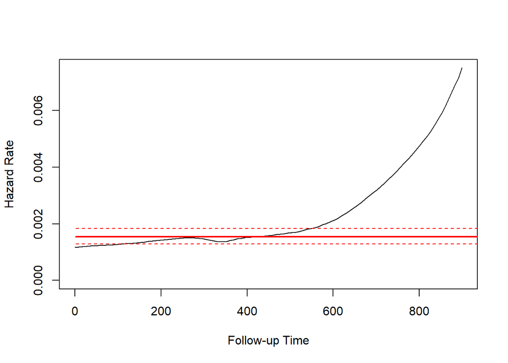

```r
plot(exp_model, type="hazard", ci=TRUE)
```

The evidence does NOT strongly support the exponential assumption. The complementary log-log plots (Question 3) showed non-linear patterns and non-parallel curves, indicating the hazard is not constant over time. Additionally, the cumulative hazard functions diverged rather than remaining linear and parallel as required by the exponential distribution.

## Question 6

```r
# Fit Weibull AFT model
weibull_aft <- flexsurvreg(Surv(survt, status) ~ clinic + prison + dose,
                           data = addicts2,
                           dist = "weibull")

# Use tidy to get results
library(broom)
weibull_tidy <- tidy(weibull_aft, exponentiate = TRUE, conf.int = TRUE)
weibull_tidy
```

```
## # A tibble: 5 × 7
##   term   estimate std.error statistic      p.value conf.low conf.high
##   <chr>     <dbl>     <dbl>     <dbl>        <dbl>    <dbl>     <dbl>
## 1 shape    1.38     0.0936      NA    NA             1.20     1.57
## 2 scale   62.3     20.6         NA    NA            32.7    119.
## 3 clinic   0.698    0.157        4.46  0.00000826    0.391    1.00
## 4 prison  -0.239    0.121       -1.98  0.0477       -0.476   -0.00245
## 5 dose     0.0243   0.00460      5.29  0.000000123   0.0153   0.0333
```

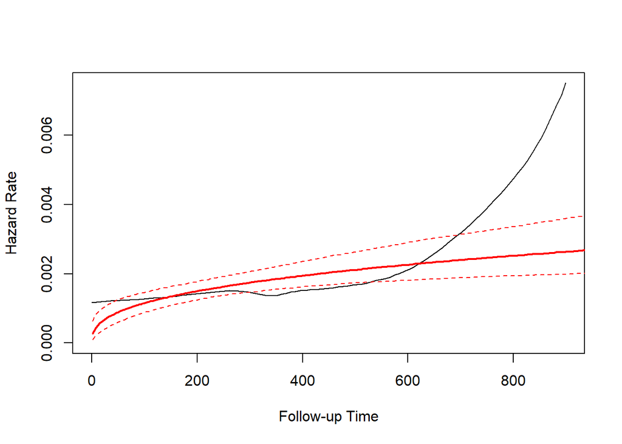

```r
plot(weibull_aft, type="hazard", ci=TRUE)
```

The Weibull model has a shape parameter = 1.38 . When shape > 1, the hazard increases over time. The exponential is actually a special case of Weibull where shape = 1 (constant hazard). Since our data has shape = 1.38, the hazard increases over time, making the Weibull a better fit than the exponential.

## 6c

```r
# Look at the shape parameter and its confidence interval
weibull_tidy[weibull_tidy$term == "shape", ]
```

```
## # A tibble: 1 × 7
##   term  estimate std.error statistic p.value conf.low conf.high
##   <chr>    <dbl>     <dbl>     <dbl>   <dbl>    <dbl>     <dbl>
## 1 shape     1.38    0.0936        NA      NA     1.20      1.57
```

```r
AIC(exp_model)
```

```
## [1] 2168.953
```

```r
AIC(weibull_aft)
```

```
## [1] 2151.676
```

Yes, the baseline hazard is significantly better approximated by the Weibull than the exponential distribution. The shape parameter confidence interval excludes 1.0, and the Weibull model has substantially better fit (lower AIC).

## 6d

```r
# Fit Weibull in proportional hazards form
weibull_ph <- flexsurvreg(Surv(survt, status) ~ clinic + prison + dose,
                          data = addicts2,
                          dist = "weibullPH")

# Get results
tidy(weibull_ph, exponentiate = TRUE, conf.int = TRUE)
```

```
## # A tibble: 5 × 7
##   term   estimate std.error statistic      p.value  conf.low conf.high
##   <chr>     <dbl>     <dbl>     <dbl>        <dbl>     <dbl>     <dbl>
## 1 shape   1.38      0.0936      NA    NA            1.20        1.57
## 2 scale   0.00338   0.00226     NA    NA            0.000917    0.0125
## 3 clinic -0.961     0.213       -4.52  0.00000620  -1.38       -0.544
## 4 prison  0.329     0.167        1.98  0.0482       0.00255     0.656
## 5 dose   -0.0335    0.00630     -5.32  0.000000105 -0.0458     -0.0211
```

```r
# Compare coefficients
library(broom)
aft_coef <- tidy(weibull_aft)[c(3:5), c("term", "estimate")]
ph_coef <- tidy(weibull_ph)[c(3:5), c("term", "estimate")]

comparison <- merge(aft_coef, ph_coef, by = "term", suffixes = c("_AFT", "_PH"))
comparison
```

```
##     term estimate_AFT estimate_PH
## 1 clinic   0.69775450 -0.96050074
## 2   dose   0.02432799 -0.03348894
## 3 prison  -0.23929673  0.32940624
```

The signs reverse because AFT and PH models parameterize effects differently: AFT (Accelerated Failure Time):

Models the effect on survival time Positive coefficient → longer survival time (slower failure) Example: clinic coefficient = +0.698 means Clinic 2 patients survive longer

PH (Proportional Hazards):

Models the effect on hazard rate (risk of failure) Positive coefficient → higher hazard (faster failure) Example: clinic coefficient = -0.961 means Clinic 2 patients have lower hazard

The relationship: Longer survival time ↔︎ Lower hazard rate So a positive AFT coefficient (longer survival) corresponds to a negative PH coefficient (lower hazard), and vice versa. They’re expressing the same relationship from opposite perspectives.

# Section II Survival Curves

```r
 library(haven)
divorce_EPI608 <- read_dta("data/divorce_EPI608.dta")
 View(divorce_EPI608)

str(divorce_EPI608)
```

```
## tibble [185,216 × 7] (S3: tbl_df/tbl/data.frame)
##  $ id      : num [1:185216] 9 9 9 9 9 9 9 9 9 9 ...
##   ..- attr(*, "label")= chr "Couple number"
##   ..- attr(*, "format.stata")= chr "%9.0g"
##  $ heduc   : dbl+lbl [1:185216] 1, 1, 1, 1, 1, 1, 1, 1, 1, 1, 1, 1, 1, 1, 1, 1, 1, ...
##    ..@ label       : chr "Education of the husband"
##    ..@ format.stata: chr "%11.0g"
##    ..@ labels      : Named num [1:2] 0 1
##    .. ..- attr(*, "names")= chr [1:2] "< 12 Years" ">= 12 Years"
##  $ heblack : dbl+lbl [1:185216] 0, 0, 0, 0, 0, 0, 0, 0, 0, 0, 0, 0, 0, 0, 0, 0, 0, ...
##    ..@ label       : chr "Whether husband is black"
##    ..@ format.stata: chr "%9.0g"
##    ..@ labels      : Named num [1:2] 0 1
##    .. ..- attr(*, "names")= chr [1:2] "No" "Yes"
##  $ mixed   : dbl+lbl [1:185216] 0, 0, 0, 0, 0, 0, 0, 0, 0, 0, 0, 0, 0, 0, 0, 0, 0, ...
##    ..@ label       : chr "Whether husband and wife have different ethnicity"
##    ..@ format.stata: chr "%9.0g"
##    ..@ labels      : Named num [1:2] 0 1
##    .. ..- attr(*, "names")= chr [1:2] "No" "Yes"
##  $ years   : num [1:185216] 1 2 3 4 5 6 7 8 9 10 ...
##   ..- attr(*, "label")= chr "Duration of marriage from wedding to divorce or censoring"
##   ..- attr(*, "format.stata")= chr "%9.0g"
##  $ div     : dbl+lbl [1:185216] 0, 0, 0, 0, 0, 0, 0, 0, 0, 0, 0, 0, 0, 0, 0, 0, 0, ...
##    ..@ label       : chr "Whether couple was divorce (failure indicator)"
##    ..@ format.stata: chr "%9.0g"
##    ..@ labels      : Named num [1:2] 0 1
##    .. ..- attr(*, "names")= chr [1:2] "No" "Yes"
##  $ yearscat: num [1:185216] 0 1 2 3 4 5 6 7 8 9 ...
##   ..- attr(*, "label")= chr "observation interval"
##   ..- attr(*, "format.stata")= chr "%9.0g"
##  - attr(*, "label")= chr "Marriage Dissolution in the U.S."
##  - attr(*, "notes")= chr [1:2] "1" "Lillard and Panis (2000). aML Multilevel Multiprocess  Statistical Software, Release 1.0, EconWare, LA, California."
```

```r
head(divorce_EPI608, 20)
```

```
## # A tibble: 20 × 7
##       id heduc           heblack   mixed     years div       yearscat
##    <dbl> <dbl+lbl>       <dbl+lbl> <dbl+lbl> <dbl> <dbl+lbl>    <dbl>
##  1     9 1 [>= 12 Years] 0 [No]    0 [No]        1 0 [No]           0
##  2     9 1 [>= 12 Years] 0 [No]    0 [No]        2 0 [No]           1
##  3     9 1 [>= 12 Years] 0 [No]    0 [No]        3 0 [No]           2
##  4     9 1 [>= 12 Years] 0 [No]    0 [No]        4 0 [No]           3
##  5     9 1 [>= 12 Years] 0 [No]    0 [No]        5 0 [No]           4
##  6     9 1 [>= 12 Years] 0 [No]    0 [No]        6 0 [No]           5
##  7     9 1 [>= 12 Years] 0 [No]    0 [No]        7 0 [No]           6
##  8     9 1 [>= 12 Years] 0 [No]    0 [No]        8 0 [No]           7
##  9     9 1 [>= 12 Years] 0 [No]    0 [No]        9 0 [No]           8
## 10     9 1 [>= 12 Years] 0 [No]    0 [No]       10 0 [No]           9
## 11     9 1 [>= 12 Years] 0 [No]    0 [No]       11 0 [No]          10
## 12     9 1 [>= 12 Years] 0 [No]    0 [No]       12 0 [No]          11
## 13     9 1 [>= 12 Years] 0 [No]    0 [No]       13 0 [No]          12
## 14     9 1 [>= 12 Years] 0 [No]    0 [No]       14 0 [No]          13
## 15     9 1 [>= 12 Years] 0 [No]    0 [No]       15 0 [No]          14
## 16     9 1 [>= 12 Years] 0 [No]    0 [No]       16 0 [No]          15
## 17     9 1 [>= 12 Years] 0 [No]    0 [No]       17 0 [No]          16
## 18     9 1 [>= 12 Years] 0 [No]    0 [No]       18 0 [No]          17
## 19     9 1 [>= 12 Years] 0 [No]    0 [No]       19 0 [No]          18
## 20     9 1 [>= 12 Years] 0 [No]    0 [No]       20 0 [No]          19
```

```r
summary(divorce_EPI608)
```

```
##        id            heduc           heblack           mixed
##  Min.   :    9   Min.   :0.0000   Min.   :0.0000   Min.   :0.0000
##  1st Qu.: 3467   1st Qu.:0.0000   1st Qu.:0.0000   1st Qu.:0.0000
##  Median : 6902   Median :1.0000   Median :0.0000   Median :0.0000
##  Mean   : 7646   Mean   :0.6155   Mean   :0.2201   Mean   :0.1771
##  3rd Qu.:11794   3rd Qu.:1.0000   3rd Qu.:0.0000   3rd Qu.:0.0000
##  Max.   :17302   Max.   :1.0000   Max.   :1.0000   Max.   :1.0000
##      years            div              yearscat
##  Min.   : 1.00   Min.   :0.000000   Min.   : 0.00
##  1st Qu.:16.00   1st Qu.:0.000000   1st Qu.:15.00
##  Median :35.00   Median :0.000000   Median :34.00
##  Mean   :35.66   Mean   :0.005572   Mean   :34.66
##  3rd Qu.:55.00   3rd Qu.:0.000000   3rd Qu.:54.00
##  Max.   :74.00   Max.   :1.000000   Max.   :73.00
```

```r
length(unique(divorce_EPI608$id))
```

```
## [1] 3371
```

```r
table(divorce_EPI608$yearscat)
```

```
##
##    0    1    2    3    4    5    6    7    8    9   10   11   12   13   14   15
## 3371 3359 3308 3241 3175 3108 3040 2966 2894 2848 2794 2750 2707 2681 2654 2627
##   16   17   18   19   20   21   22   23   24   25   26   27   28   29   30   31
## 2597 2572 2548 2529 2509 2481 2470 2449 2433 2421 2407 2396 2386 2380 2373 2368
##   32   33   34   35   36   37   38   39   40   41   42   43   44   45   46   47
## 2363 2359 2358 2353 2353 2347 2346 2344 2343 2343 2343 2341 2341 2341 2341 2341
##   48   49   50   51   52   53   54   55   56   57   58   59   60   61   62   63
## 2340 2340 2340 2339 2339 2339 2339 2339 2339 2339 2339 2339 2339 2339 2339 2339
##   64   65   66   67   68   69   70   71   72   73
## 2339 2339 2339 2339 2339 2339 2339 2339 2339 2339
```

```r
table(divorce_EPI608$div)
```

```
##
##      0      1
## 184184   1032
```

```r
table(divorce_EPI608$heduc)
```

```
##
##      0      1
##  71210 114006
```

```r
pooled_model <- glm(div ~ heduc + heblack + mixed + yearscat + heduc:yearscat,
                    data = divorce_EPI608,
                    family = binomial(link = "logit"))

# Display the model summary
summary(pooled_model)
```

```
##
## Call:
## glm(formula = div ~ heduc + heblack + mixed + yearscat + heduc:yearscat,
##     family = binomial(link = "logit"), data = divorce_EPI608)
##
## Coefficients:
##                 Estimate Std. Error z value Pr(>|z|)
## (Intercept)    -3.745740   0.076483 -48.975  < 2e-16 ***
## heduc           0.171007   0.090075   1.898 0.057631 .
## heblack        -0.049348   0.078293  -0.630 0.528496
## mixed           0.298260   0.078401   3.804 0.000142 ***
## yearscat       -0.072429   0.004157 -17.421  < 2e-16 ***
## heduc:yearscat -0.010732   0.005521  -1.944 0.051934 .
## ---
## Signif. codes:  0 '***' 0.001 '**' 0.01 '*' 0.05 '.' 0.1 ' ' 1
##
## (Dispersion parameter for binomial family taken to be 1)
##
##     Null deviance: 12770  on 185215  degrees of freedom
## Residual deviance: 11223  on 185210  degrees of freedom
## AIC: 11235
##
## Number of Fisher Scoring iterations: 10
```

```r
# Get tidy results
library(broom)
tidy(pooled_model)
```

```
## # A tibble: 6 × 5
##   term           estimate std.error statistic  p.value
##   <chr>             <dbl>     <dbl>     <dbl>    <dbl>
## 1 (Intercept)     -3.75     0.0765    -49.0   0
## 2 heduc            0.171    0.0901      1.90  5.76e- 2
## 3 heblack         -0.0493   0.0783     -0.630 5.28e- 1
## 4 mixed            0.298    0.0784      3.80  1.42e- 4
## 5 yearscat        -0.0724   0.00416   -17.4   5.67e-68
## 6 heduc:yearscat  -0.0107   0.00552    -1.94  5.19e- 2
```

Education has a time-varying effect (interaction term p = 0.052) Time decreases divorce risk (negative coefficient) Mixed race increases divorce risk

Question 2

```r
# Question 2: Create counterfactual dataset
# Double the dataset so each couple appears twice:
# Once with heduc = 0, once with heduc = 1

# Create two copies of the data
data_heduc0 <- divorce_EPI608
data_heduc0$heduc <- 0  # Set everyone to <12 years education

data_heduc1 <- divorce_EPI608
data_heduc1$heduc <- 1  # Set everyone to ≥12 years education

# Combine both datasets
counterfactual_data <- rbind(data_heduc0, data_heduc1)

# Add an identifier for which counterfactual exposure
counterfactual_data$counterfactual <- rep(c(0, 1), each = nrow(divorce_EPI608))

# Check the size
nrow(divorce_EPI608)
```

```
## [1] 185216
```

```r
nrow(counterfactual_data)
```

```
## [1] 370432
```

```r
# Verify the structure
head(counterfactual_data)
```

```
## # A tibble: 6 × 8
##      id heduc heblack   mixed     years div       yearscat counterfactual
##   <dbl> <dbl> <dbl+lbl> <dbl+lbl> <dbl> <dbl+lbl>    <dbl>          <dbl>
## 1     9     0 0 [No]    0 [No]        1 0 [No]           0              0
## 2     9     0 0 [No]    0 [No]        2 0 [No]           1              0
## 3     9     0 0 [No]    0 [No]        3 0 [No]           2              0
## 4     9     0 0 [No]    0 [No]        4 0 [No]           3              0
## 5     9     0 0 [No]    0 [No]        5 0 [No]           4              0
## 6     9     0 0 [No]    0 [No]        6 0 [No]           5              0
```

```r
tail(counterfactual_data)
```

```
## # A tibble: 6 × 8
##      id heduc heblack   mixed     years div       yearscat counterfactual
##   <dbl> <dbl> <dbl+lbl> <dbl+lbl> <dbl> <dbl+lbl>    <dbl>          <dbl>
## 1 17302     1 0 [No]    1 [Yes]      69 0 [No]          68              1
## 2 17302     1 0 [No]    1 [Yes]      70 0 [No]          69              1
## 3 17302     1 0 [No]    1 [Yes]      71 0 [No]          70              1
## 4 17302     1 0 [No]    1 [Yes]      72 0 [No]          71              1
## 5 17302     1 0 [No]    1 [Yes]      73 0 [No]          72              1
## 6 17302     1 0 [No]    1 [Yes]      74 0 [No]          73              1
```

## Question 3

```r
# Question 3: Compute predicted probabilities of remaining married
# Get predicted probability of divorce for each row
counterfactual_data$pred_div <- predict(pooled_model,
                                        newdata = counterfactual_data,
                                        type = "response")

# Convert to probability of remaining married (surviving)
counterfactual_data$pred_survive <- 1 - counterfactual_data$pred_div

# Check the predictions
head(counterfactual_data[, c("id", "yearscat", "heduc", "counterfactual",
                             "pred_div", "pred_survive")])
```

```
## # A tibble: 6 × 6
##      id yearscat heduc counterfactual pred_div pred_survive
##   <dbl>    <dbl> <dbl>          <dbl>    <dbl>        <dbl>
## 1     9        0     0              0   0.0231        0.977
## 2     9        1     0              0   0.0215        0.979
## 3     9        2     0              0   0.0200        0.980
## 4     9        3     0              0   0.0187        0.981
## 5     9        4     0              0   0.0174        0.983
## 6     9        5     0              0   0.0162        0.984
```

```r
# Summary statistics
summary(counterfactual_data$pred_survive)
```

```
##    Min. 1st Qu.  Median    Mean 3rd Qu.    Max.
##  0.9636  0.9917  0.9981  0.9945  0.9996  0.9999
```

```r
# Compare by education level
aggregate(pred_survive ~ heduc + yearscat,
          data = counterfactual_data[counterfactual_data$yearscat %in% c(0, 10, 20), ],
          FUN = mean)
```

```
##   heduc yearscat pred_survive
## 1     0        0    0.9757190
## 2     1        0    0.9713223
## 3     0       10    0.9881012
## 4     1       10    0.9873288
## 5     0       20    0.9942076
## 6     1       20    0.9944535
```

## Question 4

```r
# Question 4: Cumulatively multiply survival probabilities (simpler approach)
library(dplyr)

# Calculate cumulative survival using grouped operations
counterfactual_data <- counterfactual_data %>%
  arrange(id, counterfactual, yearscat) %>%
  group_by(id, counterfactual) %>%
  mutate(cum_survive = cumprod(pred_survive)) %>%
  ungroup()

# Check the results
head(counterfactual_data[, c("id", "yearscat", "heduc", "counterfactual",
                             "pred_survive", "cum_survive")], 20)
```

```
## # A tibble: 20 × 6
##       id yearscat heduc counterfactual pred_survive cum_survive
##    <dbl>    <dbl> <dbl>          <dbl>        <dbl>       <dbl>
##  1     9        0     0              0        0.977       0.977
##  2     9        1     0              0        0.979       0.956
##  3     9        2     0              0        0.980       0.937
##  4     9        3     0              0        0.981       0.919
##  5     9        4     0              0        0.983       0.903
##  6     9        5     0              0        0.984       0.889
##  7     9        6     0              0        0.985       0.875
##  8     9        7     0              0        0.986       0.863
##  9     9        8     0              0        0.987       0.852
## 10     9        9     0              0        0.988       0.841
## 11     9       10     0              0        0.989       0.832
## 12     9       11     0              0        0.989       0.823
## 13     9       12     0              0        0.990       0.815
## 14     9       13     0              0        0.991       0.808
## 15     9       14     0              0        0.992       0.801
## 16     9       15     0              0        0.992       0.794
## 17     9       16     0              0        0.993       0.789
## 18     9       17     0              0        0.993       0.783
## 19     9       18     0              0        0.994       0.778
## 20     9       19     0              0        0.994       0.774
```

```r
# Verify at different time points
counterfactual_data %>%
  filter(yearscat %in% c(0, 5, 10, 15, 20)) %>%
  select(id, yearscat, heduc, counterfactual, cum_survive) %>%
  head(20)
```

```
## # A tibble: 20 × 5
##       id yearscat heduc counterfactual cum_survive
##    <dbl>    <dbl> <dbl>          <dbl>       <dbl>
##  1     9        0     0              0       0.977
##  2     9        5     0              0       0.889
##  3     9       10     0              0       0.832
##  4     9       15     0              0       0.794
##  5     9       20     0              0       0.769
##  6     9        0     1              1       0.973
##  7     9        5     1              1       0.873
##  8     9       10     1              1       0.812
##  9     9       15     1              1       0.774
## 10     9       20     1              1       0.750
## 11    11        0     0              0       0.977
## 12    11        5     0              0       0.889
## 13    11       10     0              0       0.832
## 14    11       15     0              0       0.794
## 15    11       20     0              0       0.769
## 16    11        0     1              1       0.973
## 17    11        5     1              1       0.873
## 18    11       10     1              1       0.812
## 19    11       15     1              1       0.774
## 20    11       20     1              1       0.750
```

# Question 5: Average cumulative survival probabilities by year and education level

```r
# This creates the marginal survival curves

marginal_curves <- counterfactual_data %>%
  group_by(yearscat, heduc) %>%
  summarise(avg_cum_survive = mean(cum_survive),
            .groups = "drop")

# View the results
head(marginal_curves, 20)
```

```
## # A tibble: 20 × 3
##    yearscat heduc avg_cum_survive
##       <dbl> <dbl>           <dbl>
##  1        0     0           0.976
##  2        0     1           0.971
##  3        1     0           0.954
##  4        1     1           0.946
##  5        2     0           0.934
##  6        2     1           0.923
##  7        3     0           0.915
##  8        3     1           0.902
##  9        4     0           0.899
## 10        4     1           0.883
## 11        5     0           0.883
## 12        5     1           0.867
## 13        6     0           0.869
## 14        6     1           0.851
## 15        7     0           0.857
## 16        7     1           0.838
## 17        8     0           0.845
## 18        8     1           0.825
## 19        9     0           0.834
## 20        9     1           0.814
```

```r
# Check at specific time points
marginal_curves %>%
  filter(yearscat %in% c(0, 5, 10, 15, 20, 25, 30))
```

```
## # A tibble: 14 × 3
##    yearscat heduc avg_cum_survive
##       <dbl> <dbl>           <dbl>
##  1        0     0           0.976
##  2        0     1           0.971
##  3        5     0           0.883
##  4        5     1           0.867
##  5       10     0           0.824
##  6       10     1           0.804
##  7       15     0           0.786
##  8       15     1           0.765
##  9       20     0           0.760
## 10       20     1           0.740
## 11       25     0           0.742
## 12       25     1           0.724
## 13       30     0           0.731
## 14       30     1           0.714
```

## Question 6

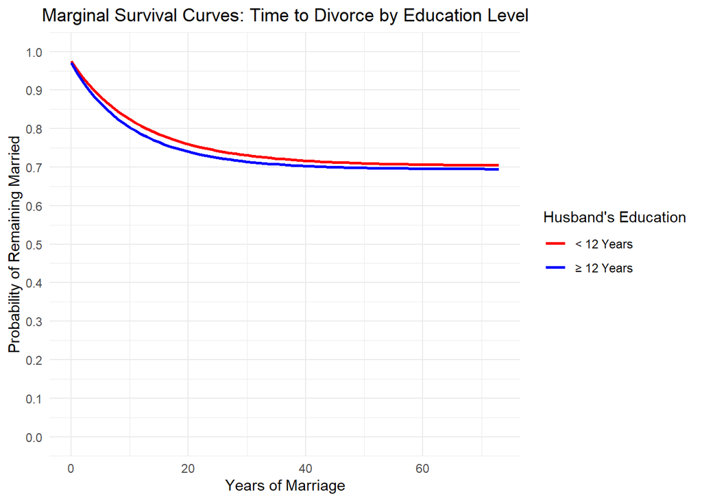

```r
# Question 6: Plot survival curves by education level
library(ggplot2)

# Create the plot
survival_plot <- ggplot(marginal_curves, aes(x = yearscat, y = avg_cum_survive,
                                              color = factor(heduc),
                                              group = factor(heduc))) +
  geom_line(linewidth = 1) +
  scale_color_manual(values = c("red", "blue"),
                     labels = c("< 12 Years", "≥ 12 Years"),
                     name = "Husband's Education") +
  labs(x = "Years of Marriage",
       y = "Probability of Remaining Married",
       title = "Marginal Survival Curves: Time to Divorce by Education Level") +
  theme_minimal() +
  theme(legend.position = "right",
        plot.title = element_text(hjust = 0.5)) +
  scale_y_continuous(limits = c(0, 1), breaks = seq(0, 1, 0.1))

# Display the plot
print(survival_plot)
```

```r
# Save the plot if needed
# ggsave("survival_curves.png", survival_plot, width = 8, height = 6)
```

## Interp 1

```r
# Compare survival probabilities at key time points
marginal_curves %>%
  filter(yearscat %in% c(10, 20, 30, 40)) %>%
  pivot_wider(names_from = heduc, values_from = avg_cum_survive, names_prefix = "heduc_")
```

```
## # A tibble: 4 × 3
##   yearscat heduc_0 heduc_1
##      <dbl>   <dbl>   <dbl>
## 1       10   0.824   0.804
## 2       20   0.760   0.740
## 3       30   0.731   0.714
## 4       40   0.717   0.703
```

Education (≥12 years) appears to be detrimental to marriage in the early years but the effect diminishes over time. The blue line (≥12 years education) is consistently below the red line (<12 years), indicating lower probability of remaining married. However, the curves converge after about 20-30 years, suggesting the negative effect of higher education weakens over time.

## Interpretation Question 2: Difference in 75th percentile of time to divorce

```r
# Find exact crossing point for 75% survival (0.75)
# For heduc = 0 (< 12 years)
marginal_curves %>%
  filter(heduc == 0, avg_cum_survive >= 0.74, avg_cum_survive <= 0.76)
```

```
## # A tibble: 6 × 3
##   yearscat heduc avg_cum_survive
##      <dbl> <dbl>           <dbl>
## 1       20     0           0.760
## 2       21     0           0.756
## 3       22     0           0.752
## 4       23     0           0.749
## 5       24     0           0.745
## 6       25     0           0.742
```

```r
# For heduc = 1 (≥ 12 years)
marginal_curves %>%
  filter(heduc == 1, avg_cum_survive >= 0.74, avg_cum_survive <= 0.76)
```

```
## # A tibble: 4 × 3
##   yearscat heduc avg_cum_survive
##      <dbl> <dbl>           <dbl>
## 1       16     1           0.759
## 2       17     1           0.753
## 3       18     1           0.749
## 4       19     1           0.744
```

## Interpretation Question 3: Effect on probability of remaining married for 10+ years

```r
# Get survival probabilities at year 10
marginal_curves %>%
  filter(yearscat == 10)
```

```
## # A tibble: 2 × 3
##   yearscat heduc avg_cum_survive
##      <dbl> <dbl>           <dbl>
## 1       10     0           0.824
## 2       10     1           0.804
```

Higher education (≥12 years) decreases the probability of remaining married for 10 years or more by 2 percentage points (from 82.4% to 80.4%). In relative terms, couples with higher-educated husbands have 97.6% of the 10-year marriage survival probability compared to those with less-educated husbands. This suggests that higher education is associated with a slightly higher risk of divorce within the first 10 years of marriage.

## Interpretation Question 4: Why are these survival curves marginal?

The survival curves are marginal because of Step 5 (averaging cumulative survival probabilities across all individuals). This step averages the predicted survival probabilities over the entire study population for each time point and education level. By doing this, we are standardizing (or weighting) the estimates according to the observed distribution of all other covariates (heblack, mixed) in the actual study population. In other words, the marginal survival curves represent what would happen if we could set everyone’s education to a specific level while maintaining their actual values for race and mixed-race status. This creates population-averaged estimates that account for the covariate distribution, rather than conditional estimates for specific covariate combinations.